# Midterm Project

Author

Maria Oljaca

# Introduction

### Background:

[Note: “Protein X” and “Protein Y” are used in place of actual protein names for data security purposes.]

This dataset originates from an experiment focused on stem cell therapy for bone regeneration, using a rat animal model. Prior research has established the effectiveness of stem cells transduced with Protein X in treating critical-sized bone defects. In rat studies, it has been established that five million cells is the standard dose needed to heal critical-sized bone defects.

This study serves a dual purpose: it seeks to ascertain whether Protein Y, an upstream protein of Protein X, can enhance the bone-healing capabilities of Protein X. Furthermore, it aims to determine whether a reduced dosage of three million cells can produce comparable bone-healing outcomes.

The study includes four distinct experimental groups: X+Y5M, X+Y3M, X5M, and X3M. Critical-sized femoral defects, created surgically in rats, were treated with either three or five million stem cells transduced with a virus encoding Protein X, or a combination of both Protein X and Y. Subsequently, the quality and quantity of bone formation in rat femurs were assessed through various methods, including biomechanical strength testing, the results of which are contained in this dataset. The key variables measured with biomechanical testing are max torque (N), torsional stiffness (Nm/deg), total energy to failure (Nm*deg), and rotation at failure or max displacement (deg).

### Question:

Which experimental group showed the greatest levels of bone regeneration, as measured by torsional stiffness, max torque, total energy to failure, and max displacement?

# Methods

The dataset used for this project was obtained from a colleague who recently conducted the above experiment. I received the results of the biomechanical testing in an Excel file via email.

```r
# Read in the data
library(readxl)
xy_bmech <- read_excel("C:/Users/molja/Downloads/XY Biomechanical Results.xlsx")
```

```r
library(tidyverse)
```

For data exploration and wrangling, I mainly used base R and the ‘dplyr’ package within tidyverse. First, I evaluated the data’s integrity, which showed that there were no apparent import issues and that the data set contains 34 rows and 5 columns: SID, Stiffness, Total Energy, Max Torque, and Max Displacement Then, I checked the variables, which revealed no major issues and variable types as expected.

```r
#Checking the dimenstions, headers, footers
dim(xy_bmech)
head(xy_bmech)
tail(xy_bmech)
# Checking variables
str(xy_bmech)
colSums(is.na(xy_bmech))
```

The imported dataset did not include the four experimental groups. However, that information was recorded in another document provided to me by my colleague, so I created the variable for experimental group and mapped each observation to its correct group.

```r
# Defining and mapping SID to Experimental Group
Exp_groups <- data.frame(
  SID = c(
    "518L", "516R", "571L", "545R", "509L", "506R", "186R", "187L", "146L",
    "195L", "122R", "182L", "179R", "178L", "142L", "141R", "172L", "553R", "145R",
    "144L", "124R", "919R", "189L", "166R", "167L", "552R", "538R", "512L", "501L",
    "193R", "592L", "510R", "129R", "150L"
  ),
  Exp_Group = c(
    "X+Y3M", "X+Y3M", "X+Y3M", "X+Y3M", "X+Y3M", "X+Y3M", "X+Y3M", "X+Y3M", "X+Y3M",
    "X3M", "X3M", "X3M", "X3M", "X3M", "X3M", "X3M", "X3M", "X5M","X5M", "X5M",        "X5M", "X5M", "X5M", "X5M", "X5M", "X5M", "X+Y5M", "X+Y5M",
    "X+Y5M", "X+Y5M", "X+Y5M", "X+Y5M", "X+Y5M", "X+Y5M"
  )
)
xy_bmech <- xy_bmech %>%
  left_join(Exp_groups, by = "SID")
```

Next, I wanted to rename the variables for ease of coding:

```r
xy_bmech <- xy_bmech %>%
  rename(Total_Energy = `Total Energy`,
         Max_Torque = `Max Torque`,
         Max_Displacement = `Max Displacement`)
```

Returning to the EDA checklist, I took a closer look at the key variables, which showed no missing data and an uneven number of observations in the experimental groups: 9 in X+Y3M and X5M, but 8 in X+Y5M and X3M.

```r
# Taking a closer look at key variables
summary(xy_bmech$Stiffness)
summary(xy_bmech$Total_Energy)
summary(xy_bmech$Max_Torque)
summary(xy_bmech$Max_Displacement)
table(xy_bmech$Exp_Group)
```

Histograms and boxplots revealed that most of the key biomechanical variables had a right-skewed distribution in addition to two or more outliers.

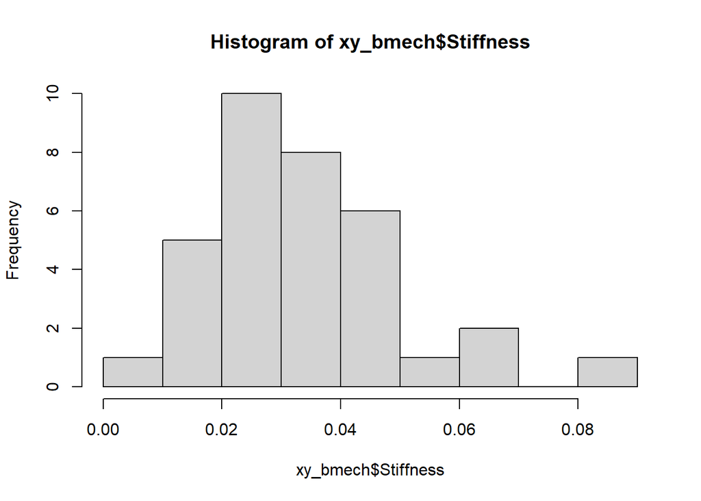

```r
hist(xy_bmech$Stiffness)
```

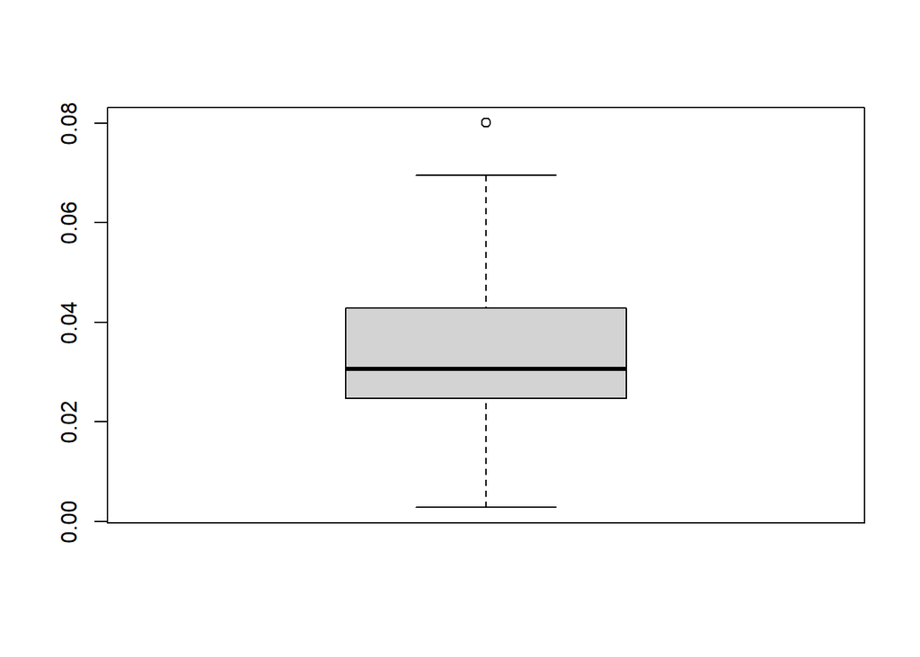

```r
boxplot(xy_bmech$Stiffness)
```

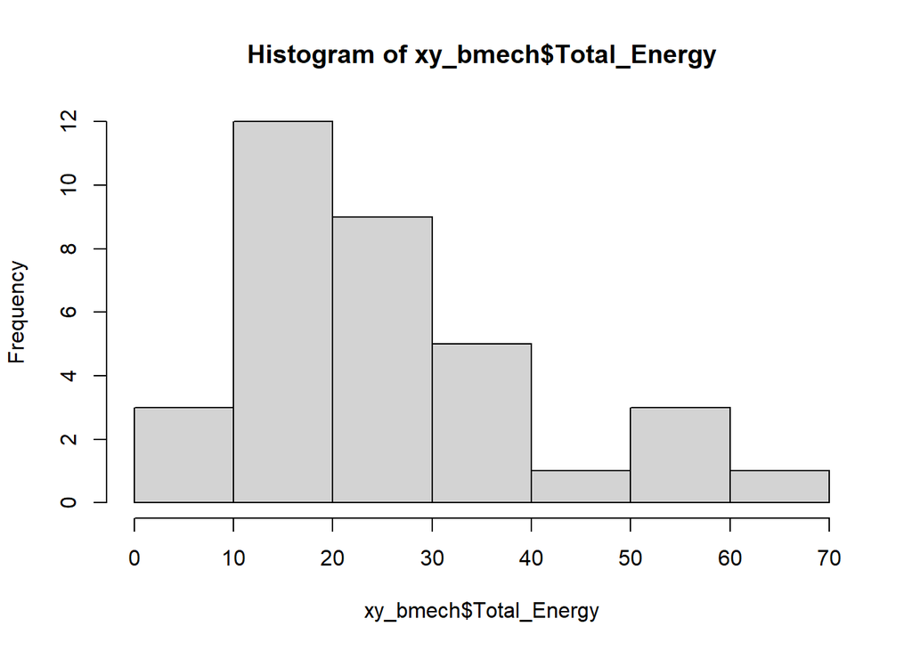

```r
hist(xy_bmech$Total_Energy)
```

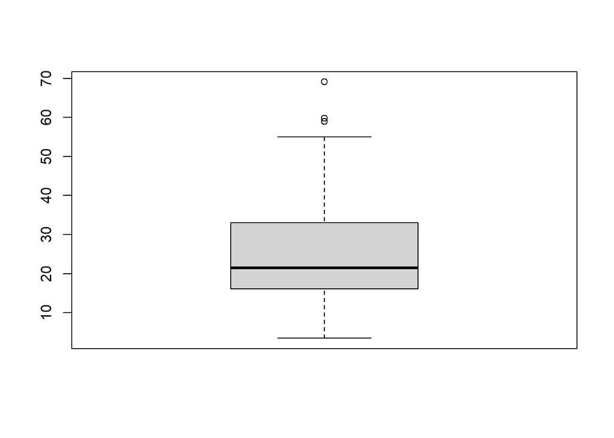

```r
boxplot(xy_bmech$Total_Energy)
```

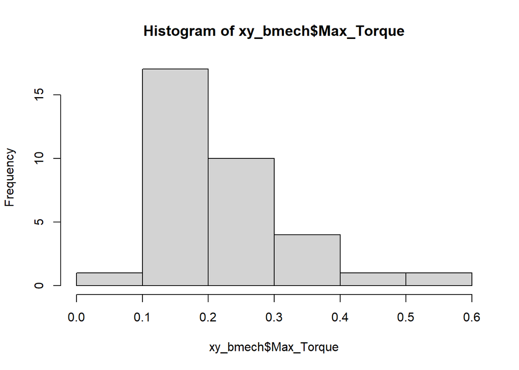

```r
hist(xy_bmech$Max_Torque)
```

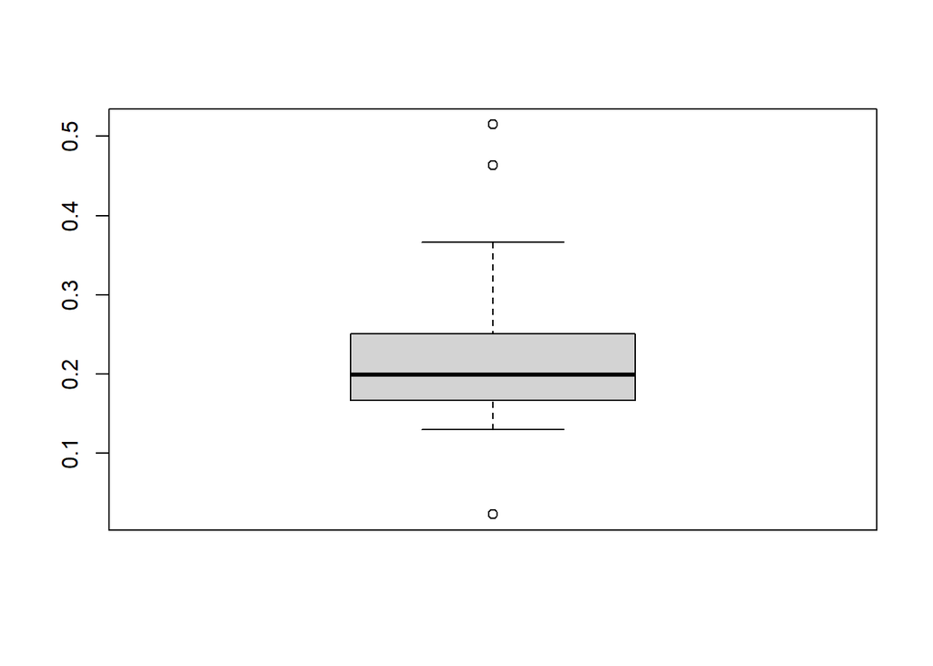

```r
boxplot(xy_bmech$Max_Torque)
```

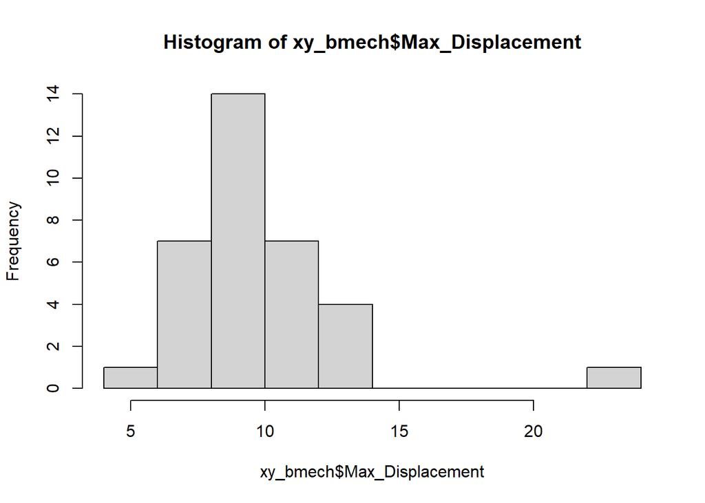

```r
hist(xy_bmech$Max_Displacement)
```

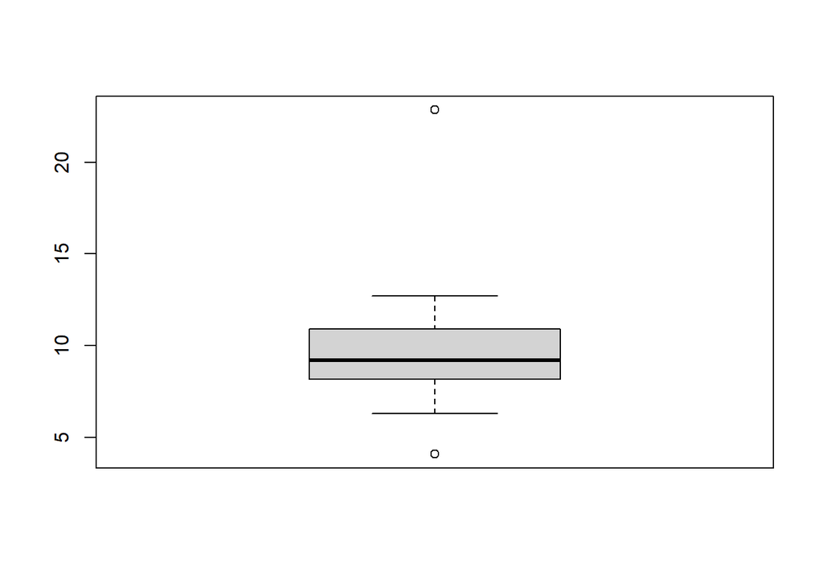

```r
boxplot(xy_bmech$Max_Displacement)
```

Per my colleague, a priori power analysis for this experiment had determined that 9 animals per group were needed, for a total of 36. However, there were 34 in this experiment because one rat was mislabeled and the other was not strong enough to undergo biomechanical testing.

Given that 9 animals per group are needed for adequate statistical power, I chose to impute values for the missing rats. Given the skewed distributions and outliers of the key variables, I chose to use median imputation. Because each experimental group received a different intervention, I also chose to impute by experimental group.

```r
# Creating data for missing rats
missing_rat1 <- data.frame(
  SID = "IMP1",
  Stiffness = median(xy_bmech$Stiffness[xy_bmech$Exp_Group == "X+Y5M"], na.rm = TRUE),
  Total_Energy = median(xy_bmech$Total_Energy[xy_bmech$Exp_Group == "X+Y5M"], na.rm = TRUE),
  Max_Torque = median(xy_bmech$Max_Torque[xy_bmech$Exp_Group == "X+Y5M"], na.rm = TRUE),
  Max_Displacement = median(xy_bmech$Max_Displacement[xy_bmech$Exp_Group == "X+Y5M"], na.rm = TRUE),
  Exp_Group = "X+Y5M"
)
missing_rat2 <- data.frame(
  SID = "IMP2",
  Stiffness = median(xy_bmech$Stiffness[xy_bmech$Exp_Group == "X3M"], na.rm = TRUE),
  Total_Energy = median(xy_bmech$Total_Energy[xy_bmech$Exp_Group == "X3M"], na.rm = TRUE),
  Max_Torque = median(xy_bmech$Max_Torque[xy_bmech$Exp_Group == "X3M"], na.rm = TRUE),
  Max_Displacement = median(xy_bmech$Max_Displacement[xy_bmech$Exp_Group == "X3M"], na.rm = TRUE),
  Exp_Group = "X3M"
)

xy_bmech <- rbind(xy_bmech, missing_rat1, missing_rat2)
```

# Preliminary Results

### Summary Statistics

```r
library(kableExtra)
summary_stats <- xy_bmech %>%
  group_by(Exp_Group) %>%
  summarize(
    "Stiffness" = paste0(round(median(Stiffness, na.rm = TRUE), 4), " (", round(IQR(Stiffness, na.rm = TRUE), 4), ")"),
    "Total Energy" = paste0(round(median(Total_Energy, na.rm = TRUE), 2), " (", round(IQR(Total_Energy, na.rm = TRUE), 2), ")"),
    "Max Torque" = paste0(round(median(Max_Torque, na.rm = TRUE), 4), " (", round(IQR(Max_Torque, na.rm = TRUE), 4), ")"),
    "Max Displacement" = paste0(round(median(Max_Displacement, na.rm = TRUE), 2), " (", round(IQR(Max_Displacement, na.rm = TRUE), 2), ")")
  )
colnames(summary_stats)[1] <- "Experimental Group"
units_df <- data.frame(
  Variable = c("Stiffness", "Total Energy", "Max Torque", "Max Displacement"),
  Unit = c("Nm/deg", "Nm*deg", "N", "deg")
)
```

```r
summary_table <- summary_stats %>%
  kable("html") %>%
  kable_styling(bootstrap_options = "striped", full_width = FALSE) %>%
  add_footnote("Values represent median (IQR)") %>%
  add_header_above(c("", units_df$Unit))
summary_table
```

| Experimental Group | Nm/deg Stiffness | Nm*deg Total Energy | N Max Torque | deg Max Displacement |
| --- | --- | --- | --- | --- |
| X+Y3M | 0.0324 (0.0129) | 17.78 (26.22) | 0.2041 (0.0742) | 10.89 (3.17) |
| X+Y5M | 0.0341 (0.0334) | 25.46 (26.29) | 0.2064 (0.1948) | 9.53 (1.56) |
| X3M | 0.0292 (0.0096) | 22.95 (8.49) | 0.2018 (0.0835) | 8.6 (1.6) |
| X5M | 0.0301 (0.0118) | 22.56 (13.84) | 0.1855 (0.0557) | 9.09 (2.22) |

<sup>a</sup> Values represent median (IQR)

### Data Visualization

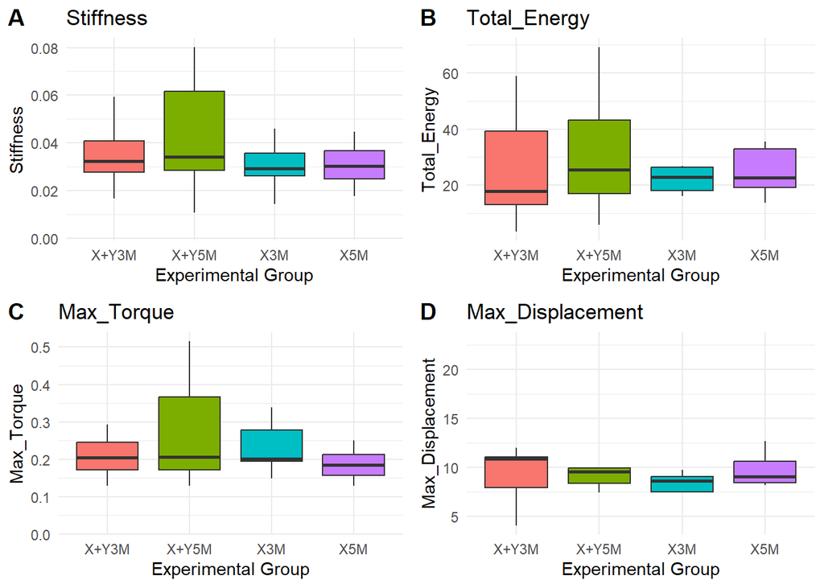

```r
box_plots <- list()

for (variable in c("Stiffness", "Total_Energy", "Max_Torque", "Max_Displacement")) {
  p <- ggplot(xy_bmech, aes(x = Exp_Group, y = .data[[variable]], fill = Exp_Group)) +
    geom_boxplot(outlier.shape = NA) +
    labs(
      title = paste(variable),
      x = "Experimental Group",
      y = variable
    ) +
    theme_minimal() +
    theme(legend.position = "none")  # Remove legend for individual plots

  box_plots[[variable]] <- p
}
combined_plots <- cowplot::plot_grid(plotlist = box_plots, ncol = 2, labels = "AUTO")
combined_plots
```

# Conclusion

Observing the summary table and boxplots, it appears that bone in the X+Y5M group performed the best on most measures of biomechanical strength, including torsional stiffness, total energy to failure, and max torque. X+Y3M outperformed X+Y5M on rotation at failure, or max displacement. The X+Y5M group also generally had the greatest variability in markers of biomechanical strength.

In general, it also appears that both of the X+Y experimental groups outperformed the X only groups on measures of biomechanical strength other than total energy to failure, in which the X+Y3M group performed the worst.

On visualization, many of these differences appear miniscule. It is not possible to form a full conclusion on which experimental treatment was most successful at bone healing until analytical statistics are applied.